# Capitulo 4 - Estadistica 2

## 4.3 **Algunas relaciones básicas de probabilidad**

### **Complemento de un evento**

Al calcular $P(A)$, se obtiene el resultado siguiente.

Cálculo de la Probabilidad utilizando el complemento

$$P(A) = 1 - P(A^c)$$

(4.5)

La ecuación anterior muestra la probabilidad de que un evento A se calcule fácilmente si se conoce la probabilidad de su complemento, $P(A^c)$. Como ejemplo, considere el caso de un gerente de ventas quien, después de revisar los informes de ventas, establece que 80% de los contactos de clientes nuevos no generan ninguna venta. Al hacer que A denote el evento de que se realiza una venta y Ac denote el evento de que no se realice, el gerente establece que $P(A^c)$ = 0.80. Utilizando la ecuación anterior, vemos que

$$P(A) = 1 - P(A^c) = 1 - 0.80 = 0.20$$

### **Ley de la adición**

La ley de la adición es útil cuando interesa conocer la probabilidad de que ocurra por lo menos uno de dos eventos. Es decir, con los eventos A y B nos interesa conocer la probabilidad de que ocurra el evento $A$ o el evento $B$, o ambos. Antes de presentar la ley de la adición, debemos estudiar dos conceptos relacionados con la combinación de eventos: la *unión* de eventos y la *intersección* de eventos. Dados dos eventos $A$ y $B$, la unión de $A$ y $B$ se define como sigue.

Unión de dos Eventos

La unión de $A$ y $B$ es el evento que contiene todos los puntos de la muestra que pertenecen a $A$ o $B$ o *ambos*. La unión se denota mediante $A ∪ B$.

**Figura 4.1** Unión de los eventos A y B

```python
import matplotlib.pyplot as plt
from matplotlib_venn import venn2
# Datos de ejemplo
A = {1,2,3,4,5}
B = {4,5,6,7,8}
union = A.union(B)
color = 'lightgreen'
venn_diagram = venn2([A,B], set_labels=('A', 'B'), set_colors=(color, color))
venn_diagram.get_label_by_id('10').set_text('')
venn_diagram.get_label_by_id('01').set_text('')
venn_diagram.get_label_by_id('11').set_text('AUB')
plt.show()
```

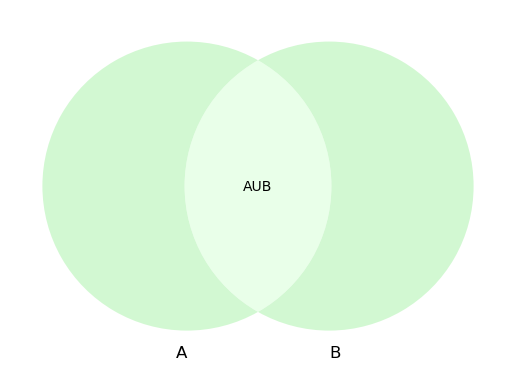

Intersección de dos Eventos

Dados dos eventos $A$ y $B$, la *intersección* de $A$ y $B$ es el evento que contiene los puntos de la muestra que pertenecen a tanto a $A$ como a $B$. La intersección se denota por medio de $A ∩ B$.

Ley de la Adición

$$P(A ∪ B) = P(A) + P(B) - P(A ∩ B)$$

(4.6)

**Figura 4.2** Intersección de los eventos A y B

```python
import matplotlib.pyplot as plt
from matplotlib_venn import venn2
# Datos de ejemplo
A = {1,2,3,4,5}
B = {4,5,6,7,8}
intersection = A.intersection(B)
color = 'lightgreen'
venn_diagram = venn2([A,B], set_labels=('A', 'B'), set_colors=(color, color))
venn_diagram.get_label_by_id('10').set_text('')
venn_diagram.get_label_by_id('01').set_text('')
venn_diagram.get_label_by_id('11').set_text('A∩B')
plt.show()
```

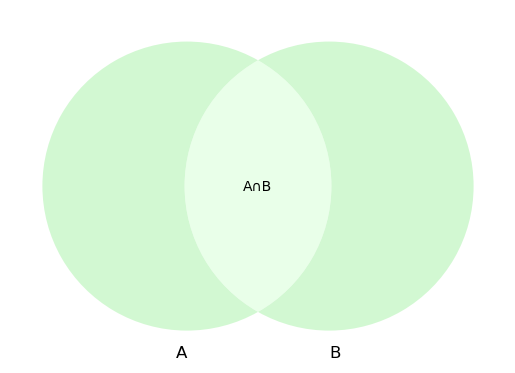

Para entender de manera intuitiva la ley de la adición, considere que los dos primeros términos de la ley, $P(A) + P(B)$, representan todos los puntos de la muestra en $A ∪ B$. Sin embargo, debido a que los puntos de la muestra en la intersección $A ∩ B$ están en $A$ y en $B$, cuando se calcula $P(A) + P(B)$, en realidad se están contando dos veces cada uno de los puntos de la muestra en $A ∩ B$. Este conteo excesivo se corrige al restar $P(A ∩ B)$.